# Introducció a l’estadística amb R

Sessió 4 · Correlació i regressió lineal

Joel Ardiaca

Centre d’Estudis d’Opinió

9 de novembre del 2026

# Benvinguda

## Què farem avui?

| Hora | Què farem |
| --- | --- |
| 9.30 | **Teoria**: correlació i, sobretot, regressió lineal |
| 10.40 | **R**: gràfics de dispersió, `cor()`, `lm()` i `predict()` |
| 11.00 | *Pausa* |
| 11.30 | **Pràctica**: correlació i regressió amb R, cadascú al seu ritme |
| 13.15 | **Tancament del curs**: què hem après i com continuar |

Fins a la pausa, **no cal obrir RStudio**: mireu i pregunteu.

## On som?

A la sessió 3 vam relacionar dues variables quan almenys una era **categòrica**. Avui, la casella que faltava:

|  | **VI categòrica** | **VI numèrica** |
| --- | --- | --- |
| **VD categòrica** | Taules de contingència, $\chi^2$ *Sessió 3* | (Regressió logística) |
| **VD numèrica** | Comparació de mitjanes: t-test, ANOVA *Sessió 3* | **Correlació i regressió** **Avui** |

**L’exemple d’avui**: les 1.068 seccions censals de Barcelona a les eleccions al Parlament del 2021. Les seccions amb més **atur**, s’abstenen més?

# Correlació

## Primer, sempre: el diagrama de dispersió

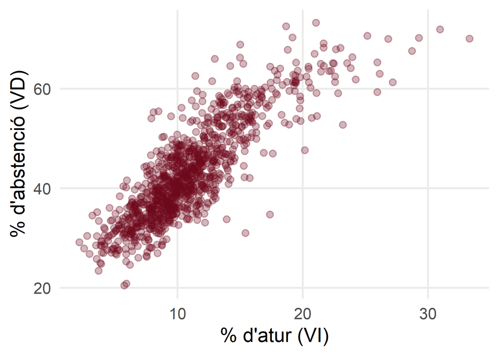

- Cada **punt** és una secció censal
- **X**: la variable independent
- **Y**: la variable dependent

Què hi busquem?

- **Direcció**: pugen o baixen juntes?
- **Forma**: és una línia recta?
- **Força**: els punts estan junts o escampats?
- Casos **estranys**

## El coeficient de correlació de Pearson: r

Un sol número que resumeix la **direcció** i la **força** d’una relació **lineal**. Va de $-1$ a $+1$:

[figure not shown]

- **Signe**: $r > 0$, pugen juntes; $r < 0$, quan una puja, l’altra baixa
- $r = 0$: **cap relació lineal**

| $\lvert r \rvert$ | Relació |
| --- | --- |
| < 0,10 | Inexistent o molt feble |
| 0,10 – 0,30 | Feble |
| 0,30 – 0,50 | Moderada |
| ≥ 0,50 | Forta |

## A Barcelona: r = 0,85

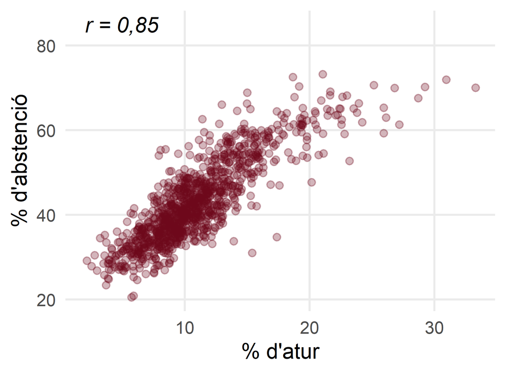

**r = 0,85**: relació **positiva** i **forta**.

Les seccions amb més atur tendeixen a tenir més abstenció.

Però abans de treure conclusions, **tres coses a tenir en compte**…

## Compte 1: només mesura relacions lineals

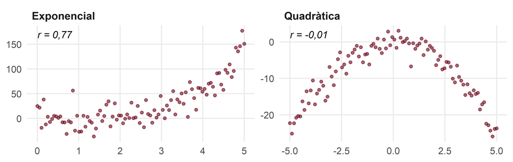

## Compte 2: els valors atípics

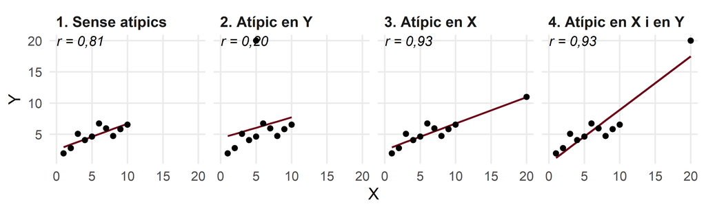

- **Un sol punt** pot canviar molt la r (i la recta)
- Cal mirar si és un **error**, un cas **extrem però vàlid** o un cas **interessant**

📖 **Per aprofundir**: la correlació pas a pas i els valors atípics

## Compte 3: correlació no és causalitat

L’atur **provoca** abstenció? No ho podem dir. Hi pot haver una **tercera variable** relacionada amb totes dues:

| Atur i abstenció | Renda i abstenció | Renda i atur |
| --- | --- | --- |
| 0,85 | -0,83 | -0,78 |

Les seccions amb **menys renda** tenen **més atur** i també **més abstenció**. Potser l’atur i l’abstenció van junts perquè tots dos depenen de la **renda**, i no perquè l’un provoqui l’altre.

## La correlació, és significativa?

Una mostra pot donar $r \neq 0$ per atzar. Amb `cor.test()` contrastem:

- $H_0$: a la població **no** hi ha correlació ($\rho = 0$)
- $H_1$: **sí** que n’hi ha

```r
cor.test(bcn$perc_atur, bcn$abstencio)
```

```
    Pearson's product-moment correlation

data:  bcn$perc_atur and bcn$abstencio
t = 51.969, df = 1066, p-value < 2.2e-16
alternative hypothesis: true correlation is not equal to 0
95 percent confidence interval:
 0.8288760 0.8629157
sample estimates:
      cor
0.8467604
```

**p < 0,001** → rebutgem $H_0$: la correlació és **significativa**. Amb 1.068 seccions, gairebé qualsevol correlació ho és: el que importa és **com de forta** és.

# Regressió lineal

## De la correlació a la recta

La correlació diu **si** hi ha relació i **com de forta** és. La regressió va més enllà:

- **Quant** canvia l’abstenció per cada punt més d’atur?
- Quina abstenció **esperem** en una secció amb un 20 % d’atur?

Busquem la **recta** que millor resumeix el núvol de punts: $\quad Y = a + b \cdot X$

## Una recta: l’intercept i el pendent

$$Y = a + b \cdot X$$

- **Intercept** ($a$): el valor de $Y$ quan $X = 0$. On la recta talla l’eix vertical
- **Pendent** ($b$): **quant canvia** $Y$ quan $X$ augmenta **una unitat**
  - $b > 0$: puja
  - $b < 0$: baixa
  - $b = 0$: plana (cap relació)

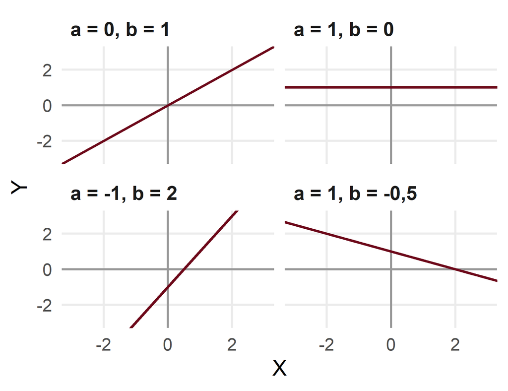

## Quina recta s’ajusta millor?

Hi podem dibuixar moltes rectes. **A ull**, quina resumeix millor el núvol de punts?

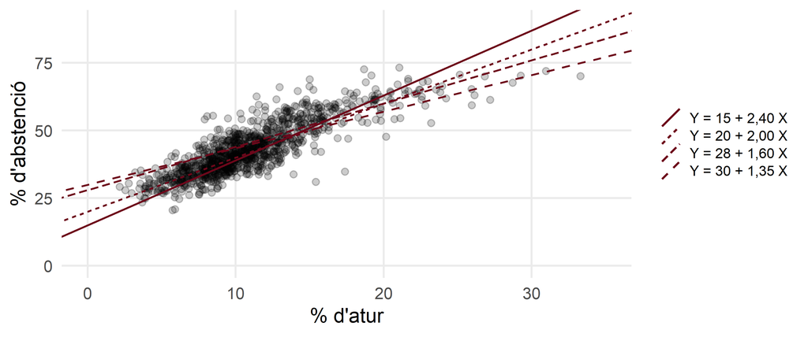

Totes passen pel mig del núvol… Necessitem un **criteri** per triar-ne una.

## El criteri: els errors més petits

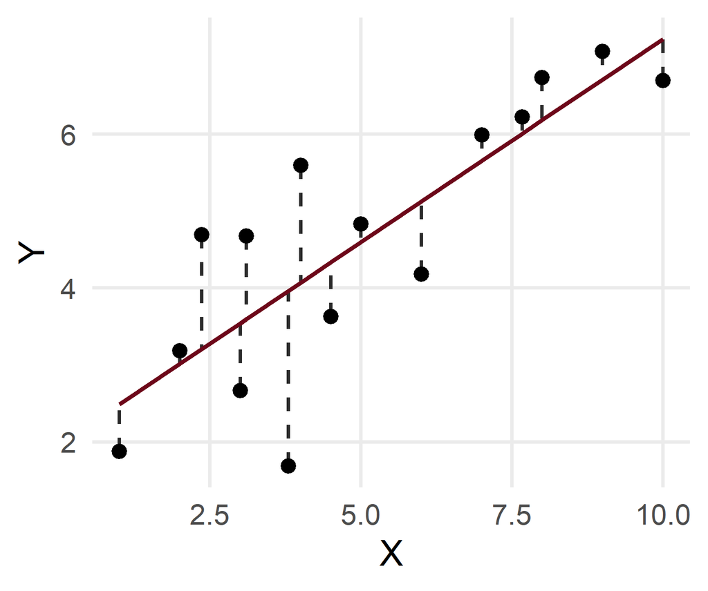

- La recta **mai** passa per tots els punts
- L’**error** o **residu** de cada punt és la distància **vertical** fins a la recta: el valor real menys el que prediu la recta
- Cada recta té els seus errors. Triem la que els fa **més petits**

**Mínims quadrats**: la recta que fa **mínima la suma dels errors al quadrat**. És la que calcula R, i no cal fer-ho a mà.

## Un exemple concret: una secció

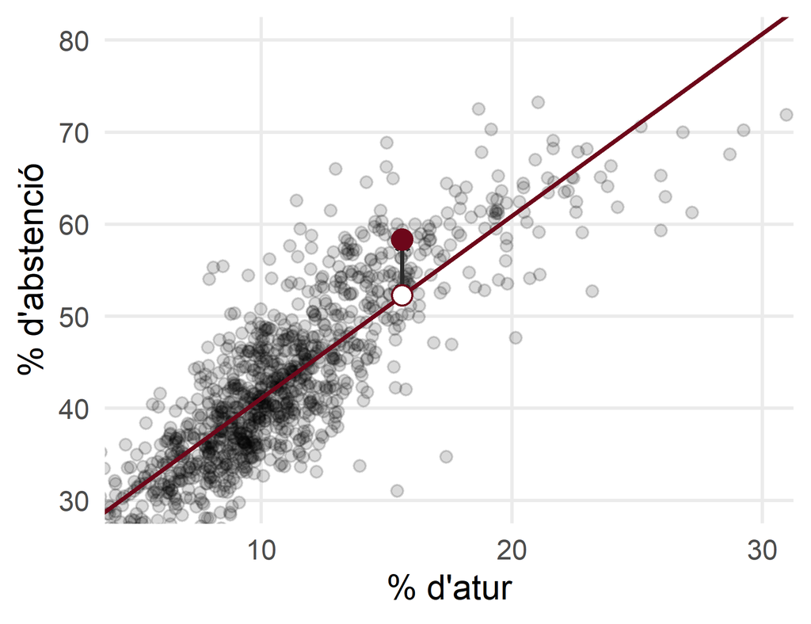

La secció **0801901001** de Barcelona:

| **Atur** (X) | 15,6 % |
| --- | --- |
| **Abstenció real** (Y) | 58,3 % |
| **Abstenció predita** per la recta | 52,3 % |
| **Residu** (real − predita) | **+6,0 punts** |

- La **predicció** (punt blanc) és el valor de la recta per a aquest atur
- El **residu** (fletxa) és el que la recta **no** explica: aquesta secció s’absté 6,0 punts **més** del que tocaria pel seu atur
- La recta de regressió és la que fa **més petits**, en conjunt, els residus de les 1.068 seccions

## La regressió amb R: `lm()`

`lm()` vol dir *linear model*. La fórmula és com la del t-test: `Y ~ X`, «abstenció **segons** atur».

```r
lm(abstencio ~ perc_atur, data = bcn)
```

```
Call:
lm(formula = abstencio ~ perc_atur, data = bcn)

Coefficients:
(Intercept)    perc_atur
      21.33         1.98
```

$$\widehat{\text{abstenció}} = 21{,}33 + 1{,}98 \cdot \text{atur}$$

- **Pendent** (1,98): per cada punt més d’atur, **1,98 punts més** d’abstenció
- **Intercept** (21,33): l’abstenció amb un 0 % d’atur (aquí no té sentit)

## Llegir el `summary()` (1): els coeficients

`summary(model)` dona molta informació. La part més important és la **taula de coeficients**:

```
            Estimate Std. Error t value Pr(>|t|)
(Intercept) 21.33351    0.44662   47.77   <2e-16 ***
perc_atur    1.97954    0.03809   51.97   <2e-16 ***
```

| Columna | Què és | Per al pendent de l’atur |
| --- | --- | --- |
| **`Estimate`** | El coeficient | +1,98 punts d’abstenció per punt d’atur |
| `Std. Error` | L’**error estàndard**: quant podria variar d’una mostra a una altra | 0,04 |
| `t value` | `Estimate` / `Std. Error` (com el t-test de la sessió 3) | 52,0 errors estàndard lluny del 0 |
| **`Pr(>\|t\|)`** | El **p-valor**. $H_0$: el pendent és 0 (cap relació) | < 0,001 → relació **significativa** |

La fila de l’**intercept** es llegeix igual, però el seu p-valor no sol interessar: contrasta si l’abstenció amb un 0 % d’atur seria 0.

## Llegir el `summary()` (2): quant explica el model

La part de baix del `summary()`:

```
Residual standard error: 5.133 on 1066 degrees of freedom
Multiple R-squared:  0.717, Adjusted R-squared:  0.7167
```

- **`Residual standard error`**: de mitjana, les prediccions s’equivoquen uns **5,1 punts** d’abstenció (la mida típica dels residus)
- **`Multiple R-squared`**: el **$R^2$**, la part de la variació de l’abstenció que explica l’atur (slide següent)

Del `summary()`, només cal mirar **tres coses**: el **`Estimate`** del pendent (quant), el seu **`Pr(>|t|)`** (és significatiu?) i el **`R-squared`** (quant explica).

📖 **Per aprofundir**: la sortida de `summary()`, número a número

## Bondat d’ajust: el $R^2$

Com de bé resumeix la recta les dades?

- Sense saber l’atur, la millor predicció seria la **mitjana** (línia discontínua)
- Amb l’atur, prediem amb la **recta**
- El $R^2$ diu **quina part de la variació** de $Y$ explica $X$: de 0 a 1

$R^2 =$ 0,72: l’atur explica el **72 %** de la variació de l’abstenció.

Amb una sola X, $R^2 = r^2$: $0{,}85^2 = 0{,}72$

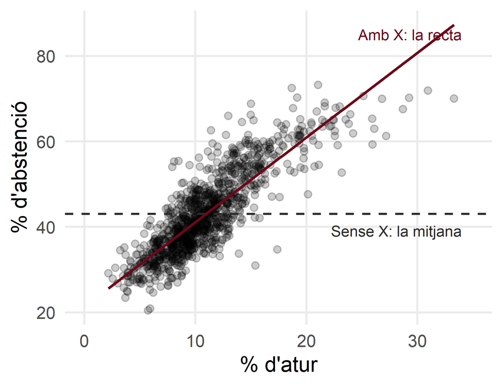

## Significatiu no vol dir que expliqui molt

Dos models per a l’abstenció a Barcelona: segons l’**atur** i segons el **% de població estrangera**.

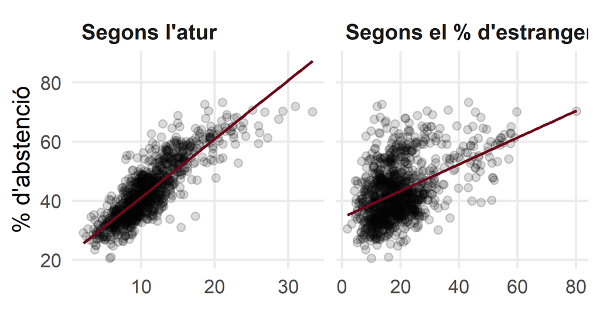

|  | Atur | Estrangers |
| --- | --- | --- |
| Pendent | 1,98 | 0,45 |
| p-valor | < 0,001 | < 0,001 |
| $R^2$ | **0,72** | **0,21** |

## Prediccions: `predict()`

Quina abstenció esperem en una secció amb un **20 % d’atur**?

```r
predict(model, newdata = tibble(perc_atur = 20))
```

```
       1
60.92432
```

`predict()` necessita els valors de X en una **taula**: `tibble()` en crea una de petita, amb una columna que es diu **igual** que la X del model (`perc_atur`).

És el mateix que posar el 20 a l’equació:

$$\widehat{\text{abstenció}} = 21{,}33 + 1{,}98 \cdot 20 = 60{,}92$$

Les prediccions només són vàlides **dins del rang de les dades**: a Barcelona, l’atur va del 2 % al 33 %. No té sentit predir l’abstenció amb un 60 % d’atur.

## I si la X és categòrica?

Les seccions de **Barcelona** i de **l’Hospitalet**, s’abstenen igual?

```r
lm(abstencio ~ municipi, data = dos_municipis)
```

```
         (Intercept) municipiL'Hospitalet
            43.06188             10.52636
```

- **Intercept** (43,1): la mitjana de la categoria de **referència** (Barcelona, la primera per ordre alfabètic)
- **Coeficient** (10,5): la **diferència de mitjanes** de l’Hospitalet respecte de Barcelona

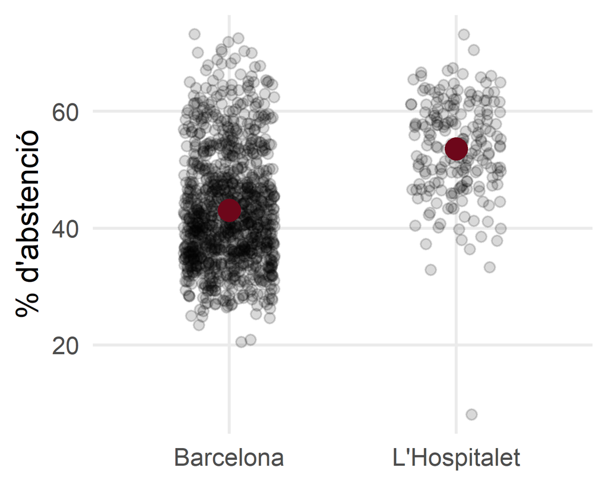

És la diferència de mitjanes de la sessió 3 (`group_by()` + `summarise()` i t-test), però el model ens la dona **directament**, sense haver-la de calcular a mà. I el p-valor del coeficient diu si és significativa, com el t-test.

## Quan no em puc fiar del model?

Perquè els p-valors i les prediccions siguin fiables, cal que:

|  | En paraules | Com ho veiem |
| --- | --- | --- |
| **L** | La relació és una **línia recta** | El diagrama de dispersió |
| **I** | Els casos són **independents** entre si | Com s’han recollit les dades |
| **N** | Els errors són **normals** (o hi ha molts casos) | Histograma dels residus |
| **E** | La dispersió és **igual** per a tota la X (no fa forma d’**embut**) | Gràfic de residus |

El més important, i el més fàcil: **mirar el gràfic** abans de fer el model. Si no és una línia, la recta no té sentit.

📖 **Per aprofundir**: els supòsits del model, pas a pas

## Per anar més enllà: regressió múltiple

Diverses X alhora: $\quad Y = a + b_1 X_1 + b_2 X_2 + \ldots$

```r
lm(abstencio ~ perc_atur + renda_persona, data = bcn)
```

|  | Pendent de l’atur |
| --- | --- |
| Només amb l’atur | 1,98 |
| Amb l’atur **i** la renda | 1,19 |

📖 **Per aprofundir**: regressió múltiple i interaccions

## Resum: quina tècnica per a què?

| Variables | Descriure | Contrastar ($H_0$: no hi ha relació) |
| --- | --- | --- |
| **2 categòriques** | % de la VD dins de cada grup de la VI | `chisq.test()` |
| **Numèrica** segons **categòrica** | Mitjana per grup | `t.test()` (2 grups), `aov()` (3 o més) |
| **2 numèriques** | Diagrama de dispersió, **r**, la **recta** | `cor.test()`, `summary(lm())` |

Sempre igual: primer **mirar** (gràfic), després **descriure** (com és la relació? és forta?) i, finalment, **contrastar** (és significativa?).

# R: correlació i regressió

## Repàs exprés

**Els verbs** (sessions 1 a 3)

| Verb | Què fa |
| --- | --- |
| `filter()` | Tria files |
| `select()` | Tria columnes |
| `rename()` | Canvia noms |
| `mutate()` | Crea columnes |
| `count()` | Compta |
| `summarise()` | Resumeix |
| `arrange()` | Ordena |
| `group_by()` | Fa el següent per a cada grup |

**Guardar o només mirar?**

```r
# Guardem: amb <-
competencies <- competencies |>
  mutate(...)

# Només mirem: sense <-
competencies |>
  summarise(...)
```

Avui hi afegim **quatre funcions** noves: el gràfic de dispersió, `cor()`, `lm()` i `predict()`.

## Novetat 1: el gràfic de dispersió

Una **plantilla** per copiar: només cal canviar les **dades** i les **variables**.

```r
# Dades i variables de cada eix...
ggplot(competencies, aes(x = nota_cat, y = nota_ang)) +
```

```r
  # ...un punt per alumne...
  geom_point() +
```

```r
  # ...i la recta de regressió
  geom_smooth(method = "lm")
```

**Compte**: entre les capes d’un gràfic va **`+`**, no `|>`. I el `+` sempre al **final** de la línia.

## El resultat

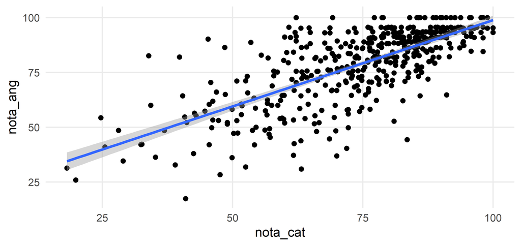

Cada punt és un alumne. La franja grisa és l’interval de confiança de la recta. R avisa que ha tret 18 alumnes sense nota: no és cap error.

## Novetat 2: `cor()` dins de `summarise()`

`cor(x, y)` calcula la correlació. Com que és un **resum**, va dins de `summarise()`:

```r
# Agafa les dades i després...
competencies |>
```

```r
  # ...treu els alumnes sense nota (NA)...
  filter(!is.na(nota_cat), !is.na(nota_ang)) |>
```

```r
  # ...i calcula la correlació
  summarise(r = cor(nota_cat, nota_ang))
```

```
# A tibble: 1 × 1
      r
  <dbl>
1 0.726
```

Per què el `filter()`? Si hi ha **un sol `NA`**, `cor()` torna `NA` (com `mean()`). Amb `filter(!is.na(...))` ens quedem només amb els alumnes que tenen **totes dues** notes.

## `cor()` per grups: `group_by()`

El mateix d’abans, però **per a cada gènere**:

```r
competencies |>
  filter(!is.na(nota_cat), !is.na(nota_ang)) |>
```

```r
  # ...per a cada gènere...
  group_by(genere) |>
```

```r
  # ...quants alumnes i quina correlació
  summarise(n = n(),
            r = cor(nota_cat, nota_ang))
```

```
# A tibble: 2 × 3
  genere     n     r
  <chr>  <int> <dbl>
1 Dona     240 0.731
2 Home     222 0.716
```

El `group_by()` de la sessió 3 funciona amb **qualsevol** resum: mitjanes, comptes… i correlacions.

## Novetat 3: `lm()`, guardar el model

El model té molta informació: el **guardem en un objecte** i després en traiem el que vulguem.

```r
# Ajustem el model i el guardem
model_cat <- lm(nota_ang ~ nota_cat,
                data = competencies)
```

```r
# Els coeficients
coef(model_cat)
```

```r
# El resum complet (Estimate, p-valors, R²)
summary(model_cat)
```

```
(Intercept)    nota_cat
   20.21367     0.78669
```

Per cada punt més de català, la nota d’anglès és, de mitjana, **0,79 punts** més alta. El `summary()` el mirarem a la pràctica.

`lm()` treu sol els alumnes amb `NA` (i ho diu al `summary()`): aquí no cal el `filter()`.

## Novetat 4: `predict()`

Quina nota d’anglès esperem amb un **50** i amb un **90** de català?

```r
# Els valors de X per als quals volem la predicció, en una taula (tibble)...
predict(model_cat, newdata = tibble(nota_cat = c(50, 90)))
```

```
       1        2
59.54817 91.01577
```

Amb un 50 de català, esperem un **59,5** d’anglès; amb un 90, un **91,0**. Dins de `tibble()`, el nom ha de ser **el mateix** que el de la X del model.

## Xuleta: correlació i regressió amb R

| Vull… | Codi |
| --- | --- |
| Diagrama de dispersió | `ggplot(dades, aes(x = X, y = Y)) + geom_point()` |
| … amb la recta | `+ geom_smooth(method = "lm")` |
| Correlació | `filter(!is.na(X), !is.na(Y)) \|> summarise(r = cor(X, Y))` |
| Correlació per grups | `... \|> group_by(grup) \|> summarise(r = cor(X, Y))` |
| Model de regressió | `model <- lm(Y ~ X, data = dades)` |
| Coeficients i resum | `coef(model)`, `summary(model)` |
| Predicció | `predict(model, newdata = tibble(X = valor))` |

**Opcional**, per saber si és significativa: `cor.test(dades$X, dades$Y)` i la columna `Pr(>|t|)` del `summary()`.

# Pausa ☕

# Pràctica: correlació i regressió amb R

## Pas a pas: obrir els materials de la sessió 4

1. Descarregueu el **zip** de la sessió 4 de la web del curs
2. **Descomprimiu-lo**: botó dret → *Extreu-ho tot*. No treballeu des de dins del zip!
3. Entreu a la carpeta descomprimida i feu **doble clic** a `sessio_4.Rproj`
4. Comproveu que a dalt a la dreta de RStudio hi diu **`sessio_4`**
5. Al panell *Files* (a baix a la dreta), obriu la carpeta `codi/` i l’script `exercici_sessio_4.R`
6. Executeu el **pas 1**, que ja està fet: ha de sortir una taula de 480 files

Les dades (`dades/competencies.csv`) són les **mateixes dades netes** de les sessions 2 i 3. A `codi/01_correlacio_regressio.R` hi ha tot el codi de les slides.

## Pràctica: cadascú al seu ritme

Tot és a la plantilla `codi/exercici_sessio_4.R`:

|  | Què farem | Amb… |
| --- | --- | --- |
| **Pas 1** | Importar les dades (**ja fet**: només cal executar-lo) | `read_csv2()` |
| **Part A** · passos 2 a 5 | Les notes de català i d’anglès, van juntes? I per grups? | `ggplot()`, `cor()`, `group_by()` |
| **Part B** · passos 6 a 9 | La nota d’anglès segons la de català; la de mates segons la titularitat; és significatiu? | `lm()`, `predict()`, `cor.test()` |
| *Opcional 1* | **Anàlisi de les seccions censals**: abstenció, atur i renda en 4 municipis, amb menys pistes | Tot el que sabeu |
| *Opcional 2* | Tutorial: gràfics de dispersió amb `ggplot2` | `ggplot()` |

El codi **nou** (gràfics, `lm()`, `summary()`, `predict()`, `cor.test()`) **ja hi és**: executeu-lo i **interpreteu-lo**. El que ja sabeu fer (`filter()`, `summarise()`, `group_by()`…) l’escriviu vosaltres.

## Part A: correlació

Els alumnes que treuen bona nota de català, també en treuen d’anglès?

**Pas 2. Gràfic de dispersió** de la nota de català (X) i la d’anglès (Y), amb la recta (*ja fet*). La relació és positiva o negativa? Sembla forta?

**Pas 3. Correlació** entre català i anglès (*ja fet*). Com és la relació: feble, moderada o forta?

**Pas 4. Les tres parelles**: copieu el pas 3 per a català-matemàtiques i matemàtiques-anglès. Quina relació és més forta?

**Pas 5. Per grups**: la correlació entre català i anglès, és igual per a nois i noies? Afegiu `group_by(genere)` al pas 3. I per titularitat?

Escriviu les respostes **en paraules**, amb comentaris (`#`). La xuleta i `codi/01_correlacio_regressio.R` us fan de guia.

## Part B: regressió lineal

**Pas 6. Model** de la nota d’anglès segons la de català (*ja fet*). Al `summary()`: què vol dir el pendent? I l’intercept? El pendent, és significatiu? Quant explica ($R^2$)?

**Pas 7. Prediccions** amb un 50 i un 90 de català (*ja fet*). Té sentit predir amb un 0 de català? Calculeu la nota de català més baixa amb `summarise()` i `min()`.

**Pas 8. Una X categòrica**: el model de la nota de mates segons la titularitat (*ja fet*) i, ara vosaltres, la mitjana per titularitat amb `group_by()` + `summarise()`. Què vol dir el coeficient?

**Pas 9. És significativa la correlació?** `cor.test()` (*ja fet*): interpreteu el p-valor i l’interval de confiança.

**Lliurament**: l’script `exercici_sessio_4.R` complet i comentat, per **correu electrònic** a joelardiacaarnau@gencat.cat.

## Ja ho teniu? Part opcional

**Opcional 1. Anàlisi de les seccions censals** (`dades/seccions_censals.csv`: 1.469 seccions de Badalona, Barcelona, Girona i l’Hospitalet). Tot el que hem fet al curs, amb **menys pistes**:

1. **Descriure**: per a cada municipi, l’abstenció, l’atur i la renda mitjanes. Quin municipi s’absté més?
2. **Correlacions**: amb quina variable està més relacionada l’abstenció, amb l’atur, els estrangers o la renda?
3. **Per municipi**: la correlació entre la renda i l’abstenció, és igual als quatre municipis?
4. **Regressió simple**: l’abstenció segons la renda (en milers d’euros). Quant baixa per cada 1.000 €? Quina abstenció esperem amb 15.000 € i amb 25.000 €?
5. **X categòrica**: Badalona i Girona, s’abstenen igual? Amb `lm()` i amb `t.test()`: coincideixen?
6. **Regressió múltiple**: l’abstenció segons l’atur **i** la renda. L’efecte de l’atur, canvia?
7. **Conclusions** en paraules, amb les limitacions

**Opcional 2.** El tutorial de gràfics de dispersió amb `ggplot2`: colors per grup, un gràfic per grup, el model i els residus al gràfic.

## Quan alguna cosa falla

| Què passa | Per què | Solució |
| --- | --- | --- |
| La correlació surt `NA` | Hi ha valors perduts | `filter(!is.na(X), !is.na(Y))` abans del `summarise()` |
| Error amb `\|>` al gràfic | Entre les capes va `+` | Canvieu `\|>` per `+` |
| Només surt el gràfic buit | Falta `geom_point()` | Afegiu-lo amb `+` |
| `object 'nota_cat' not found` a `lm()` | Falta dir quines dades | `lm(Y ~ X, data = competencies)` |
| `object 'model' not found` | No heu guardat el model | `model <- lm(...)` |
| Avís «*Removed 18 rows*» al gràfic | Alumnes sense nota | No és cap error |

## El teu torn (100’)

1. **Part A**: passos 2 a 5 (gràfic i correlació)
2. **Part B**: passos 6 a 9 (regressió i significació)
3. **Ja ho teniu tot?** La part opcional del final de l’script:
   - L’**anàlisi de les seccions censals**, amb menys pistes
   - El tutorial de gràfics de dispersió

Mentre treballeu aniré passant per les taules. Si us encalleu, aviseu!

# Tancament del curs

## Què hem après al curs?

| Pas | Què fem | Amb R | Sessió |
| --- | --- | --- | --- |
| **1. Importar i mirar** | Llegir les dades i veure què hi ha | `read_csv2()`, `glimpse()` | 1 |
| **2. Netejar** | Triar, reanomenar, recodificar, filtrar | `select()`, `rename()`, `mutate()`, `filter()` | 1 |
| **3. Descriure** | Freqüències, mitjanes, dispersió | `count()`, `summarise()` | 2 |
| **4. Inferir** | De la mostra a la població | `t.test()`, `prop.test()` | 2 |
| **5. Relacionar** | Comparar grups i relacionar variables | `group_by()`, `chisq.test()`, `cor()`, `lm()` | 3 i 4 |
| **6. Interpretar** | Què vol dir? És gran? És significatiu? | **Vosaltres!** | Totes |

L’objectiu no era memoritzar codi: era **entendre què fem amb les dades** i **interpretar** bé els resultats.

## Cap on anar després?

El que **no** hem vist, i per on començar si ho necessiteu:

| Tema | Per a què serveix | On aprendre’n |
| --- | --- | --- |
| **Informes amb Quarto** | Text, codi, taules i gràfics en un sol document (com aquesta web i aquestes slides) | [quarto.org](https://quarto.org/docs/get-started/) |
| **Més gràfics** | Gràfics de tota mena amb `ggplot2` | Els tutorials del curs; [R4DS, cap. 1](https://r4ds.hadley.nz/data-visualize.html) |
| **Dades amples i llargues** | `pivot_wider()` i `pivot_longer()`: per exemple, posar dones i homes en columnes per restar-los | [R4DS, cap. 5](https://r4ds.hadley.nz/data-tidy.html) |
| **Unir taules** | `left_join()`: ajuntar dues bases de dades per una variable comuna (un codi de municipi…) | [R4DS, cap. 19](https://r4ds.hadley.nz/joins.html) |
| **Regressió logística** | Quan la **VD és categòrica** (vota o no vota): la casella buida de la taula de tècniques | `glm(..., family = binomial)` |
| **Enquestes amb pesos** | Les enquestes ponderades (com les del CEO) necessiten els **pesos** per calcular bé | Paquet [`srvyr`](https://cran.r-project.org/package=srvyr) |

*R4DS*: *R for Data Science*, el llibre de referència del tidyverse, gratuït en línia.

## Com continuar sols

### Quan us encalleu

- **`?funcio`** (o `F1`): l’ajuda de qualsevol funció, amb exemples al final
- **Llegiu l’error**: sovint diu exactament què falla (un nom mal escrit, un `NA`, una coma…)
- **Busqueu l’error** copiant-lo tal com surt: segur que algú ja l’ha tingut
- **Partiu d’un script que funcioni** (els del curs!) i canvieu-lo a poc a poc

### Per aprendre més

- **[R for Data Science](https://r4ds.hadley.nz/)**: el llibre de referència, gratuït
- **[Xuletes de Posit](https://posit.co/resources/cheatsheets/)**: `dplyr`, `ggplot2`…
- La pàgina de **Recursos** del curs
- **Practiqueu** amb dades que us interessin: el CEO, l’Idescat, dades obertes…

## Gràcies!

### Lliuraments

- Exercici de la sessió 4 per **correu electrònic** a joelardiacaarnau@gencat.cat
- Les **solucions** de totes les sessions són (o seran) a la web del curs

### Certificat

- Assistència mínima del **75 %**
- Lliurament dels **exercicis pràctics**

Totes les slides, dades, codi i explicacions continuaran a la web del curs. **Gràcies per la vostra participació!**